# Are merger recipients better off? Model methods and results

November 21, 2026

How do nonprofits that absorb another organization through a merger fare afterwards? This report estimates changes in revenue, assets, profitability, spending relative to assets, and employment for recipients in two-party mergers, compared with matched organizations that did not merge. Matching and the sample are described in `matching-report.html`.

# Methods

## Two ways to define “better off”

Absorbing a donor adds its assets, revenue, and staff to the recipient’s books, so a recipient’s size rises mechanically. That gives two reasonable questions, which we estimate side by side:

- **Recipient alone.** *Did the recipient grow?* Before and after are both the recipient’s own figures. This includes the absorbed donor, so it measures growth from the recipient’s point of view.
- **Pro forma.** *Is the merged organization more than the sum of its parts?* “Before” adds the donor’s figures to the recipient’s, each on its own fiscal calendar. “After” is the recipient alone. A value of zero means the combined organization held onto everything the two had separately, relative to controls.

The pro forma version is estimated twice:

- with controls matched to the recipient alone (the original match);
- with controls re-matched to the combined size of recipient plus donor.

## Specification

**Long difference (headline).** For organization *i* in matched set *s*:

$$\Delta y_{is} = y_{is,t+2} - y_{is,t-2}
= \alpha_s + \beta\, \text{Merger}_i + \varepsilon_{is}$$

- α<sub>s</sub> is a fixed effect for each matched set: one recipient and its same-year controls. Because controls share the recipient’s calendar year, α<sub>s</sub> also absorbs year effects.
- Recipients have weight 1, and each control has weight 1/k within its set.
- Standard errors are clustered two ways, by matched set and by organization, because a control can appear in more than one set.
- Only sets with a recipient and at least one control observed in both years are used.

**Event study.** For years t-3 to t+2, with t-2 as the reference:

$$y_{ist} = \mu_{is} + \lambda_{s,t} +
\sum_{k \neq -2} \beta_k\, \text{Merger}_i \cdot 1[t = k] +
\varepsilon_{ist}$$

The coefficient at t-3 is the pre-trend test. t0 is a transition year (partial-year books, assets arriving, one-time contribution revenue), so we read results at t+1 and t+2.

**Heterogeneity.** The long difference is re-estimated with Merger interacted with:

- the transfer size: fair market value transferred as a share of the recipient’s assets at t-2;
- recipient size band;
- affiliation;
- CEO outcome;
- board outcome.

Each group’s coefficient is its own effect relative to its own controls.

## Outcomes

| Outcome | Definition |
| --- | --- |
| Log revenue | log of total revenue, 2024 dollars |
| Log assets | log of total assets (end of year), 2024 dollars |
| Operating margin | (revenue − expenses) / revenue, bounded to −1..1 |
| Log(expenses / assets) | trimmed at the 1st and 99th percentiles |
| Log(1 + employees) | Part V employee count; full Form 990 filers only |

**Reading the coefficients.** Log coefficients are converted to percent changes, exp(β) − 1, relative to controls over the same years. For example, 0.244 is +27.7% and −0.062 is −6.0%. Margin coefficients are in percentage points. Tables show the percent change with significance stars (*** p < .01, ** p < .05, * p < .1), and the log-point estimate with its standard error underneath.

# Results

## Event study

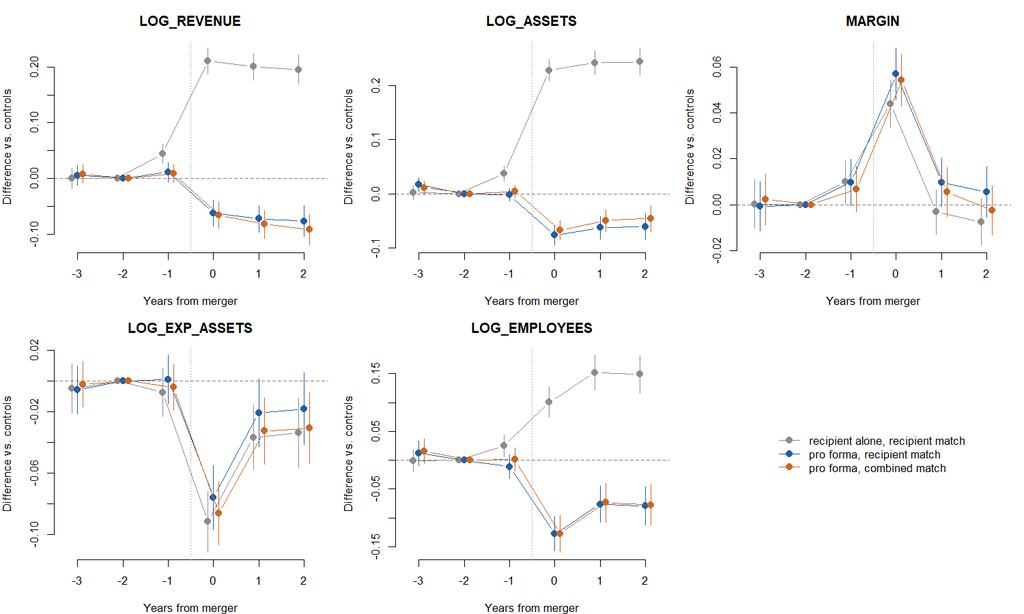

Pre-trend: coefficient at t-3 (reference t-2)

| outcome | Recipient alone | Pro forma, recipient match | Pro forma, combined match |
| --- | --- | --- | --- |
| Log assets | 0.002 (0.007) | 0.017 (0.006) | 0.011 (0.006) |
| Log revenue | -0.000 (0.009) | 0.005 (0.009) | 0.008 (0.009) |
| Log(1 + employees) | -0.001 (0.010) | 0.012 (0.011) | 0.015 (0.011) |
| Log(expenses / assets) | -0.005 (0.008) | -0.006 (0.008) | -0.002 (0.008) |
| Operating margin | 0.000 (0.005) | -0.001 (0.006) | 0.002 (0.006) |

## Main effects

Long difference t-2 to t+2. Matched sets: 3,971 (recipient match), 3,356 (combined match)

| Outcome | Recipient alone | Pro forma, recipient match | Pro forma, combined match |
| --- | --- | --- | --- |
| Log revenue | +21.7%*** 0.196 (0.013) | -7.4%*** -0.076 (0.014) | -8.5%*** -0.089 (0.014) |
| Log assets | +27.7%*** 0.244 (0.013) | -6.0%*** -0.062 (0.013) | -4.3%*** -0.044 (0.012) |
| Operating margin | -0.7 pts -0.007 (0.005) | +0.5 pts 0.005 (0.006) | -0.2 pts -0.002 (0.005) |
| Log(expenses / assets) | -3.2%*** -0.033 (0.012) | -1.6% -0.016 (0.012) | -2.9%** -0.030 (0.012) |
| Log(1 + employees) | +16.1%*** 0.149 (0.016) | -8.0%*** -0.084 (0.017) | -7.3%*** -0.076 (0.018) |

Baseline size of recipients and of recipient + donor combined

| Base | Measure | p25 | Median | p75 |
| --- | --- | --- | --- | --- |
| recipient | revenue | $1.0m | $5.2m | $24.0m |
| recipient | assets | $1.2m | $7.3m | $36.4m |
| recipient | employees | 6 | 38 | 250 |
| combined | revenue | $1.6m | $6.8m | $28.7m |
| combined | assets | $2.0m | $10.1m | $46.4m |
| combined | employees | 9 | 54 | 296 |

Implied changes at those sizes (dollars in millions, 2024 dollars; employees in people). Recipient alone applies the change to the recipient’s size; pro forma applies it to the combined size

| Design | Measure | Change | p25 | Median | p75 |
| --- | --- | --- | --- | --- | --- |
| Recipient alone | assets | +27.7% | +0.32m | +2.03m | +10.09m |
| Pro forma, recipient match | assets | -6.0% | -0.12m | -0.60m | -2.77m |
| Pro forma, combined match | assets | -4.3% | -0.09m | -0.44m | -2.01m |
| Recipient alone | employees | +16.1% | +1 | +6 | +40 |
| Pro forma, recipient match | employees | -8.0% | -1 | -4 | -24 |
| Pro forma, combined match | employees | -7.3% | -1 | -4 | -22 |
| Recipient alone | revenue | +21.7% | +0.23m | +1.12m | +5.19m |
| Pro forma, recipient match | revenue | -7.4% | -0.12m | -0.50m | -2.11m |
| Pro forma, combined match | revenue | -8.5% | -0.13m | -0.58m | -2.43m |

**Recipient alone.** Recipients grow substantially compared with similar organizations that did not merge. Two years on, the median recipient has about $2m more in assets, $1.1m more in revenue, and 6 more employees. Most of this is the donor’s books arriving: the growth rises steeply with transfer size (below).

**Pro forma.** The merged organization ends up slightly smaller than the two organizations were separately:

- assets about 4–6% smaller;
- revenue 7–9% smaller;
- staff about 8% smaller.

Roughly, 1 + 1 ≈ 1.9 after two years. Re-matching controls on the combined size barely changes this, so the shortfall is not caused by controls being the wrong size.

**Profitability does not change.** Operating margin is flat in every version. It spikes at t0 (about +5 points) as the donated assets are booked as one-time contribution revenue, then returns to zero. Expenses-to-assets falls 2–3%, because assets grow more than spending.

## By transfer size

Long difference by transfer size

| Outcome | Transfer / recipient assets | Recipient alone | Pro forma, recipient match | Pro forma, combined match |
| --- | --- | --- | --- | --- |
| Log revenue | 1-10% | +13.3%*** 0.125 (0.022) | -6.4%*** -0.066 (0.024) | -7.7%*** -0.080 (0.025) |
| Log revenue | 10-50% | +23.3%*** 0.209 (0.025) | -5.3%** -0.054 (0.027) | -6.5%*** -0.067 (0.025) |
| Log revenue | <1% | +5.1%** 0.050 (0.025) | -7.9%*** -0.083 (0.027) | -6.8%*** -0.071 (0.027) |
| Log revenue | >=50% | +70.5%*** 0.533 (0.041) | -11.2%*** -0.119 (0.043) | -14.5%*** -0.156 (0.042) |
| Log revenue | unknown | +23.3%*** 0.209 (0.066) | -5.1% -0.052 (0.071) | -7.8% -0.082 (0.069) |
| Log assets | 1-10% | +7.3%*** 0.071 (0.018) | -3.5%* -0.036 (0.020) | -3.1% -0.031 (0.021) |
| Log assets | 10-50% | +25.4%*** 0.226 (0.026) | -6.4%** -0.067 (0.029) | -6.7%** -0.070 (0.027) |
| Log assets | <1% | +4.1%** 0.041 (0.018) | -4.4%** -0.045 (0.019) | -2.8% -0.028 (0.018) |
| Log assets | >=50% | +145.4%*** 0.898 (0.041) | -13.2%*** -0.141 (0.041) | -7.4%** -0.077 (0.038) |
| Log assets | unknown | +26.3%*** 0.233 (0.058) | +1.9% 0.018 (0.053) | +3.9% 0.038 (0.048) |
| Operating margin | 1-10% | -1.1 pts -0.011 (0.009) | -0.4 pts -0.004 (0.010) | -1.6 pts -0.016 (0.010) |
| Operating margin | 10-50% | -1.1 pts -0.011 (0.010) | +0.4 pts 0.004 (0.011) | -0.1 pts -0.001 (0.010) |
| Operating margin | <1% | +0.2 pts 0.002 (0.010) | +1.5 pts 0.015 (0.010) | +1.2 pts 0.012 (0.010) |
| Operating margin | >=50% | -1.6 pts -0.016 (0.015) | -0.8 pts -0.008 (0.017) | -1.2 pts -0.012 (0.016) |
| Operating margin | unknown | +2.1 pts 0.021 (0.021) | +5.0 pts** 0.050 (0.025) | +3.3 pts 0.033 (0.023) |
| Log(expenses / assets) | 1-10% | +6.7%*** 0.064 (0.018) | -2.5% -0.025 (0.020) | -1.9% -0.019 (0.019) |
| Log(expenses / assets) | 10-50% | -0.8% -0.008 (0.022) | -0.1% -0.001 (0.025) | -1.0% -0.010 (0.024) |
| Log(expenses / assets) | <1% | +3.3% 0.032 (0.020) | -3.1% -0.031 (0.021) | -2.2% -0.022 (0.021) |
| Log(expenses / assets) | >=50% | -29.3%*** -0.347 (0.038) | +2.1% 0.021 (0.039) | -5.5% -0.057 (0.035) |
| Log(expenses / assets) | unknown | -0.3% -0.003 (0.052) | -9.7%* -0.102 (0.055) | -12.2%** -0.130 (0.050) |
| Log(1 + employees) | 1-10% | +15.3%*** 0.142 (0.026) | -3.4% -0.034 (0.030) | -2.9% -0.029 (0.030) |
| Log(1 + employees) | 10-50% | +17.9%*** 0.165 (0.032) | -9.7%*** -0.102 (0.033) | -10.4%*** -0.110 (0.035) |
| Log(1 + employees) | <1% | +4.8% 0.047 (0.031) | -9.2%*** -0.096 (0.034) | -9.1%*** -0.096 (0.035) |
| Log(1 + employees) | >=50% | +34.9%*** 0.299 (0.056) | -13.4%*** -0.143 (0.051) | -8.6%* -0.090 (0.052) |
| Log(1 + employees) | unknown | +28.3%*** 0.249 (0.076) | -2.2% -0.022 (0.087) | -2.8% -0.028 (0.085) |

Recipient-alone growth tracks the size of the transfer. Assets grow about 4% when the transfer is under 1% of the recipient’s assets, and about 145% when it is half or more. The pro forma revenue shortfall appears in every band, even the smallest. So donors were larger at t-2 than what they finally handed over: they shrink before dissolving.

## By recipient size

Long difference by recipient size

| Outcome | Recipient assets (baseline) | Recipient alone | Pro forma, recipient match | Pro forma, combined match |
| --- | --- | --- | --- | --- |
| Log revenue | $10-100m | +7.3%*** 0.070 (0.021) | -6.8%*** -0.071 (0.021) | -6.6%*** -0.068 (0.022) |
| Log revenue | <$10m | +35.3%*** 0.302 (0.021) | -9.2%*** -0.096 (0.023) | -11.2%*** -0.119 (0.022) |
| Log revenue | >=$100m | +6.6%*** 0.064 (0.018) | -1.6% -0.016 (0.019) | -1.9% -0.019 (0.018) |
| Log assets | $10-100m | +11.4%*** 0.108 (0.015) | -5.3%*** -0.054 (0.015) | -3.9%*** -0.040 (0.015) |
| Log assets | <$10m | +44.6%*** 0.369 (0.021) | -8.2%*** -0.085 (0.021) | -5.7%*** -0.059 (0.020) |
| Log assets | >=$100m | +6.9%*** 0.067 (0.017) | +0.9% 0.009 (0.016) | -0.0% -0.000 (0.016) |
| Operating margin | $10-100m | -0.8 pts -0.008 (0.008) | -0.6 pts -0.006 (0.009) | -0.5 pts -0.005 (0.009) |
| Operating margin | <$10m | -0.6 pts -0.006 (0.008) | +1.4 pts 0.014 (0.009) | +0.0 pts 0.000 (0.008) |
| Operating margin | >=$100m | -0.8 pts -0.008 (0.010) | -0.7 pts -0.007 (0.011) | -0.6 pts -0.006 (0.010) |
| Log(expenses / assets) | $10-100m | -1.8% -0.018 (0.015) | -0.6% -0.006 (0.017) | -1.4% -0.014 (0.017) |
| Log(expenses / assets) | <$10m | -5.2%*** -0.053 (0.019) | -2.3% -0.024 (0.020) | -4.3%** -0.044 (0.019) |
| Log(expenses / assets) | >=$100m | +1.3% 0.013 (0.018) | -1.2% -0.012 (0.018) | -1.1% -0.011 (0.017) |
| Log(1 + employees) | $10-100m | +7.8%*** 0.075 (0.028) | -12.5%*** -0.133 (0.031) | -12.2%*** -0.130 (0.031) |
| Log(1 + employees) | <$10m | +24.6%*** 0.220 (0.022) | -4.8%** -0.049 (0.024) | -3.7% -0.038 (0.024) |
| Log(1 + employees) | >=$100m | +7.8% 0.075 (0.046) | -8.8%* -0.092 (0.047) | -8.5%* -0.089 (0.048) |

The largest recipients ($100m+ in assets) come closest to keeping the full combined assets and revenue: their pro forma estimates are near zero, with some loss of staff. Mid-size recipients ($10–100m) shed the most staff in the pro forma comparison. Small recipients (under $10m) grow the most on their own books and show the largest pro forma revenue loss.

## By affiliation

Long difference by affiliation

| Outcome | Pair | Recipient alone | Pro forma, recipient match | Pro forma, combined match |
| --- | --- | --- | --- | --- |
| Log revenue | Affiliated | +11.9%*** 0.112 (0.020) | -10.1%*** -0.106 (0.020) | -11.5%*** -0.122 (0.021) |
| Log revenue | Arm’s length | +30.3%*** 0.265 (0.018) | -4.9%** -0.050 (0.020) | -5.9%*** -0.060 (0.019) |
| Log assets | Affiliated | +22.2%*** 0.201 (0.019) | -8.4%*** -0.087 (0.017) | -6.7%*** -0.069 (0.017) |
| Log assets | Arm’s length | +32.3%*** 0.280 (0.018) | -3.8%** -0.039 (0.019) | -2.3% -0.024 (0.018) |
| Operating margin | Affiliated | -1.4 pts* -0.014 (0.008) | -1.0 pts -0.010 (0.008) | -1.0 pts -0.010 (0.008) |
| Operating margin | Arm’s length | -0.1 pts -0.001 (0.007) | +1.8 pts** 0.018 (0.008) | +0.5 pts 0.005 (0.007) |
| Log(expenses / assets) | Affiliated | -6.9%*** -0.071 (0.017) | -0.8% -0.008 (0.017) | -2.9%* -0.029 (0.017) |
| Log(expenses / assets) | Arm’s length | -0.1% -0.001 (0.016) | -2.4% -0.024 (0.018) | -3.0%* -0.030 (0.016) |
| Log(1 + employees) | Affiliated | +7.7%*** 0.074 (0.027) | -11.5%*** -0.122 (0.027) | -10.2%*** -0.108 (0.028) |
| Log(1 + employees) | Arm’s length | +24.2%*** 0.216 (0.020) | -4.7%** -0.048 (0.023) | -4.5%** -0.046 (0.023) |

Mergers within one family of organizations show less recipient-alone growth and larger pro forma losses. Part of that is mechanical: an affiliated donor’s revenue often includes grants from the parent or a sister organization, so adding donor and recipient revenue counts some money twice. Arm’s-length mergers show a small margin gain in the pro forma version with the recipient match.

## By CEO outcome

Long difference by CEO outcome (single-donor mergers with both CEOs identified)

| Outcome | CEO outcome | Recipient alone | Pro forma, recipient match | Pro forma, combined match |
| --- | --- | --- | --- | --- |
| Log revenue | both_ceos | +35.1%*** 0.301 (0.051) | -1.5% -0.015 (0.045) | -3.4% -0.034 (0.052) |
| Log revenue | donor_ceo_only | +32.2%*** 0.279 (0.079) | -7.6% -0.079 (0.060) | -7.6% -0.079 (0.066) |
| Log revenue | neither | +27.1%*** 0.240 (0.055) | -3.9% -0.040 (0.060) | -5.1% -0.052 (0.058) |
| Log revenue | recipient_ceo_only | +26.0%*** 0.231 (0.024) | -0.7% -0.007 (0.025) | -0.3% -0.003 (0.026) |
| Log revenue | shared_ceo | +13.5%*** 0.127 (0.036) | -10.1%*** -0.107 (0.037) | -14.3%*** -0.155 (0.036) |
| Log assets | both_ceos | +33.2%*** 0.287 (0.057) | -2.3% -0.023 (0.050) | -5.4% -0.055 (0.049) |
| Log assets | donor_ceo_only | +35.9%*** 0.306 (0.101) | -14.0%* -0.151 (0.080) | -9.9% -0.104 (0.075) |
| Log assets | neither | +17.8%*** 0.164 (0.062) | -4.4% -0.045 (0.053) | -7.3% -0.076 (0.054) |
| Log assets | recipient_ceo_only | +25.0%*** 0.223 (0.025) | +0.3% 0.003 (0.024) | +2.3% 0.022 (0.024) |
| Log assets | shared_ceo | +28.7%*** 0.252 (0.032) | -4.2%* -0.043 (0.025) | -4.4%* -0.045 (0.027) |
| Operating margin | both_ceos | -2.1 pts -0.021 (0.026) | -1.8 pts -0.018 (0.028) | -1.1 pts -0.011 (0.028) |
| Operating margin | donor_ceo_only | +1.0 pts 0.010 (0.028) | +2.3 pts 0.023 (0.030) | -1.4 pts -0.014 (0.028) |
| Operating margin | neither | +2.3 pts 0.023 (0.022) | +2.9 pts 0.029 (0.026) | +0.8 pts 0.008 (0.023) |
| Operating margin | recipient_ceo_only | +0.3 pts 0.003 (0.011) | +2.7 pts** 0.027 (0.013) | +1.2 pts 0.012 (0.012) |
| Operating margin | shared_ceo | -1.8 pts -0.018 (0.012) | -1.6 pts -0.016 (0.013) | -2.2 pts -0.022 (0.013) |
| Log(expenses / assets) | both_ceos | +4.0% 0.039 (0.052) | +3.4% 0.033 (0.052) | +1.8% 0.018 (0.050) |
| Log(expenses / assets) | donor_ceo_only | -2.7% -0.027 (0.083) | +7.0% 0.068 (0.073) | +4.2% 0.041 (0.068) |
| Log(expenses / assets) | neither | +6.1% 0.060 (0.059) | -1.7% -0.017 (0.056) | -1.6% -0.016 (0.047) |
| Log(expenses / assets) | recipient_ceo_only | +0.0% 0.000 (0.023) | -3.6% -0.037 (0.024) | -3.6% -0.036 (0.024) |
| Log(expenses / assets) | shared_ceo | -8.2%*** -0.085 (0.029) | -3.5% -0.035 (0.026) | -5.5%** -0.057 (0.027) |
| Log(1 + employees) | both_ceos | +37.6%*** 0.320 (0.076) | -8.0% -0.084 (0.073) | -10.6% -0.112 (0.074) |
| Log(1 + employees) | donor_ceo_only | +54.3%*** 0.434 (0.151) | -13.4% -0.143 (0.088) | +3.1% 0.030 (0.069) |
| Log(1 + employees) | neither | +24.8%*** 0.221 (0.071) | -16.3%** -0.178 (0.085) | -19.2%** -0.213 (0.087) |
| Log(1 + employees) | recipient_ceo_only | +24.8%*** 0.222 (0.036) | -9.8%** -0.104 (0.044) | -10.3%** -0.108 (0.045) |
| Log(1 + employees) | shared_ceo | +7.7% 0.075 (0.048) | -14.6%*** -0.158 (0.048) | -13.4%*** -0.144 (0.049) |

**Recipient keeps its CEO vs. both CEOs remain.** Recipient-alone growth is similar in the two groups:

- revenue +26% when only the recipient’s CEO remains, and +35% when both remain;
- assets +25% and +33%;
- employees +25% and +38%.

The point estimates are larger when both CEOs stay. That fits larger donors whose operations and leaders both come across. But the two groups’ confidence intervals overlap, and only 1562 sets are estimated in total across all CEO groups.

In the pro forma comparison, mergers where only the recipient’s CEO remains are the closest to “1 + 1 = 2”: assets and revenue are about zero, and margin is +2.7 points with the recipient match. Mergers where the two organizations already shared a CEO show the smallest recipient-alone growth and the largest pro forma revenue loss, consistent with affiliated deals.

## By board outcome

Long difference by board outcome

| Outcome | Board outcome | Recipient alone | Pro forma, recipient match | Pro forma, combined match |
| --- | --- | --- | --- | --- |
| Log revenue | combine_major | +42.9%*** 0.357 (0.055) | -13.2%** -0.142 (0.057) | -15.7%*** -0.171 (0.055) |
| Log revenue | combine_minor | +26.1%*** 0.232 (0.023) | -1.1% -0.011 (0.025) | -3.0% -0.030 (0.025) |
| Log revenue | intact_donor_dissolves | +13.1%*** 0.123 (0.019) | -8.2%*** -0.085 (0.021) | -8.3%*** -0.087 (0.021) |
| Log revenue | recipient_turnover | +29.8%*** 0.261 (0.035) | -10.6%*** -0.112 (0.037) | -12.7%*** -0.136 (0.035) |
| Log assets | combine_major | +69.5%*** 0.528 (0.047) | +2.5% 0.025 (0.036) | +1.5% 0.015 (0.036) |
| Log assets | combine_minor | +31.6%*** 0.275 (0.024) | -2.7% -0.027 (0.023) | -0.6% -0.006 (0.022) |
| Log assets | intact_donor_dissolves | +16.6%*** 0.154 (0.019) | -8.3%*** -0.087 (0.020) | -5.5%*** -0.057 (0.020) |
| Log assets | recipient_turnover | +37.6%*** 0.319 (0.034) | -7.7%*** -0.080 (0.031) | -8.2%*** -0.085 (0.027) |
| Operating margin | combine_major | -5.2 pts*** -0.052 (0.019) | -5.2 pts** -0.052 (0.023) | -5.4 pts*** -0.054 (0.020) |
| Operating margin | combine_minor | +0.6 pts 0.006 (0.010) | +1.9 pts* 0.019 (0.011) | +0.8 pts 0.008 (0.010) |
| Operating margin | intact_donor_dissolves | -0.6 pts -0.006 (0.008) | +0.6 pts 0.006 (0.008) | +0.4 pts 0.004 (0.008) |
| Operating margin | recipient_turnover | -0.8 pts -0.008 (0.013) | +1.1 pts 0.011 (0.014) | -0.8 pts -0.008 (0.014) |
| Log(expenses / assets) | combine_major | -4.7% -0.048 (0.044) | -1.9% -0.020 (0.040) | -4.6% -0.047 (0.039) |
| Log(expenses / assets) | combine_minor | -3.6%* -0.037 (0.022) | +0.7% 0.007 (0.023) | -1.4% -0.015 (0.021) |
| Log(expenses / assets) | intact_donor_dissolves | -3.2%* -0.032 (0.017) | -3.0%* -0.030 (0.018) | -4.2%** -0.043 (0.017) |
| Log(expenses / assets) | recipient_turnover | -2.6% -0.027 (0.030) | -1.2% -0.012 (0.034) | -1.5% -0.015 (0.031) |
| Log(1 + employees) | combine_major | +41.3%*** 0.346 (0.067) | -3.6% -0.036 (0.059) | -3.5% -0.035 (0.055) |
| Log(1 + employees) | combine_minor | +24.7%*** 0.221 (0.033) | -3.6% -0.036 (0.033) | -1.5% -0.015 (0.034) |
| Log(1 + employees) | intact_donor_dissolves | +7.9%*** 0.076 (0.023) | -9.8%*** -0.103 (0.026) | -10.0%*** -0.105 (0.027) |
| Log(1 + employees) | recipient_turnover | +17.9%*** 0.165 (0.042) | -10.6%*** -0.112 (0.042) | -10.4%*** -0.110 (0.042) |

- **The recipient’s board stays intact and the donor’s board dissolves.** This is the most common pattern. It has the smallest recipient-alone growth: revenue +13%, assets +17%, employees +8%. In the pro forma comparison it loses about 8% of revenue and 10% of staff. It looks like an absorption.
- **The boards combine (`combine_minor`, `combine_major`).** Recipient-alone growth is larger: assets +32% and +70%. With a minor share of donor seats, the merged organization holds onto its combined assets, revenue, and staff in the pro forma comparison (estimates near zero).
- **Donor members take 20% or more of the seats (`combine_major`).** These are mergers of near-equals. Margin falls about 5 points and pro forma revenue falls about 13–16%. Integration seems to be costlier.
- **The recipient’s board turns over.** This shows large recipient-alone growth but pro forma losses similar to the intact-board group.

These governance categories are observed after the merger. They are descriptive, not causal: a combined board may reflect a larger or more equal deal, rather than produce a better outcome.

# Robustness: merger years through 2021

Mergers in 2022 and 2023 have post-periods that run into 2024 and 2025, and 2025 is only partly filed. Calendar-year effects on the t-2 to t+2 change are jointly significant for every outcome, and margins are lower in windows ending in 2024 and 2025. This check re-runs every model with merger years 2011 to 2021 only: 3,390 recipients in the recipient match (2,837 in the combined match), compared with 3,971 and 3,356 in the main sample.

Main effects: all merger years vs. merger years through 2021 (percent change, or percentage points for margin)

| Outcome | Recipient alone: All years | Recipient alone: Through 2021 | Pro forma, recipient match: All years | Pro forma, recipient match: Through 2021 | Pro forma, combined match: All years | Pro forma, combined match: Through 2021 |
| --- | --- | --- | --- | --- | --- | --- |
| Log revenue | +21.7%*** | +22.4%*** | -7.4%*** | -6.4%*** | -8.5%*** | -7.4%*** |
| Log assets | +27.7%*** | +27.2%*** | -6.0%*** | -6.4%*** | -4.3%*** | -4.3%*** |
| Operating margin | -0.7 pts | -0.0 pts | +0.5 pts | +1.0 pts | -0.2 pts | +0.4 pts |
| Log(expenses / assets) | -3.2%*** | -3.1%** | -1.6% | -0.8% | -2.9%** | -2.4%* |
| Log(1 + employees) | +16.1%*** | +15.5%*** | -8.0%*** | -8.1%*** | -7.3%*** | -6.8%*** |

CEO outcome splits, all years vs. through 2021

| Outcome | Group | Recipient alone: All years | Recipient alone: Through 2021 | Pro forma, recipient match: All years | Pro forma, recipient match: Through 2021 | Pro forma, combined match: All years | Pro forma, combined match: Through 2021 |
| --- | --- | --- | --- | --- | --- | --- | --- |
| Log revenue | both_ceos | +35.1%*** | +36.3%*** | -1.5% | -0.1% | -3.4% | -2.9% |
| Log revenue | donor_ceo_only | +32.2%*** | +34.3%*** | -7.6% | -3.3% | -7.6% | -2.4% |
| Log revenue | neither | +27.1%*** | +34.3%*** | -3.9% | +0.8% | -5.1% | -2.6% |
| Log revenue | recipient_ceo_only | +26.0%*** | +28.4%*** | -0.7% | +1.4% | -0.3% | +1.3% |
| Log revenue | shared_ceo | +13.5%*** | +11.9%*** | -10.1%*** | -12.9%*** | -14.3%*** | -15.2%*** |
| Log assets | both_ceos | +33.2%*** | +31.5%*** | -2.3% | -4.0% | -5.4% | -6.6% |
| Log assets | donor_ceo_only | +35.9%*** | +27.8%*** | -14.0%* | -14.6%** | -9.9% | -9.7% |
| Log assets | neither | +17.8%*** | +20.0%*** | -4.4% | -2.2% | -7.3% | -5.7% |
| Log assets | recipient_ceo_only | +25.0%*** | +24.5%*** | +0.3% | -0.5% | +2.3% | +1.7% |
| Log assets | shared_ceo | +28.7%*** | +28.3%*** | -4.2%* | -6.0%** | -4.4%* | -5.6%** |
| Operating margin | both_ceos | -2.1 pts | -1.4 pts | -1.8 pts | -1.2 pts | -1.1 pts | -0.5 pts |
| Operating margin | donor_ceo_only | +1.0 pts | +2.1 pts | +2.3 pts | +3.5 pts | -1.4 pts | +0.0 pts |
| Operating margin | neither | +2.3 pts | +3.6 pts | +2.9 pts | +4.2 pts | +0.8 pts | +2.5 pts |
| Operating margin | recipient_ceo_only | +0.3 pts | +1.9 pts* | +2.7 pts** | +4.8 pts*** | +1.2 pts | +2.7 pts** |
| Operating margin | shared_ceo | -1.8 pts | -1.4 pts | -1.6 pts | -1.3 pts | -2.2 pts | -1.2 pts |

Board outcome splits, all years vs. through 2021

| Outcome | Group | Recipient alone: All years | Recipient alone: Through 2021 | Pro forma, recipient match: All years | Pro forma, recipient match: Through 2021 | Pro forma, combined match: All years | Pro forma, combined match: Through 2021 |
| --- | --- | --- | --- | --- | --- | --- | --- |
| Log revenue | combine_major | +42.9%*** | +47.1%*** | -13.2%** | -12.9%** | -15.7%*** | -14.6%*** |
| Log revenue | combine_minor | +26.1%*** | +24.6%*** | -1.1% | -1.9% | -3.0% | -4.0% |
| Log revenue | intact_donor_dissolves | +13.1%*** | +14.2%*** | -8.2%*** | -6.7%*** | -8.3%*** | -6.2%*** |
| Log revenue | recipient_turnover | +29.8%*** | +31.9%*** | -10.6%*** | -8.4%** | -12.7%*** | -11.4%*** |
| Log assets | combine_major | +69.5%*** | +72.7%*** | +2.5% | +2.4% | +1.5% | +1.8% |
| Log assets | combine_minor | +31.6%*** | +29.8%*** | -2.7% | -4.1%* | -0.6% | -2.5% |
| Log assets | intact_donor_dissolves | +16.6%*** | +15.8%*** | -8.3%*** | -8.8%*** | -5.5%*** | -4.7%** |
| Log assets | recipient_turnover | +37.6%*** | +40.3%*** | -7.7%*** | -6.6%** | -8.2%*** | -7.3%*** |
| Operating margin | combine_major | -5.2 pts*** | -5.2 pts*** | -5.2 pts** | -5.0 pts** | -5.4 pts*** | -4.9 pts** |
| Operating margin | combine_minor | +0.6 pts | +0.8 pts | +1.9 pts* | +2.2 pts* | +0.8 pts | +1.3 pts |
| Operating margin | intact_donor_dissolves | -0.6 pts | +0.3 pts | +0.6 pts | +1.2 pts | +0.4 pts | +1.1 pts |
| Operating margin | recipient_turnover | -0.8 pts | +0.2 pts | +1.1 pts | +2.0 pts | -0.8 pts | -0.4 pts |

Event study for operating margin (reference t-2)

| design | run | -3 | -1 | 0 | 1 | 2 |
| --- | --- | --- | --- | --- | --- | --- |
| Recipient alone | All years | 0.000 | 0.010 | 0.044 | -0.003 | -0.008 |
| Recipient alone | Through 2021 | 0.007 | 0.012 | 0.046 | 0.002 | -0.001 |
| Pro forma, recipient match | All years | -0.001 | 0.010 | 0.057 | 0.010 | 0.006 |
| Pro forma, recipient match | Through 2021 | 0.002 | 0.010 | 0.058 | 0.014 | 0.011 |
| Pro forma, combined match | All years | 0.002 | 0.007 | 0.054 | 0.005 | -0.002 |
| Pro forma, combined match | Through 2021 | 0.005 | 0.008 | 0.056 | 0.010 | 0.003 |

# Interpretation and caveats

- **Both versions are informative.** From the recipient’s point of view, mergers are growth: substantial, lasting, and with no loss of operating margin. From the combined point of view, the merged organization keeps about 92–95% of the two organizations’ joint revenue and assets after two years, with about 8% fewer staff. Neither is “the” answer. The recipient-alone version overstates the gain, and the pro forma version likely overstates the loss.
- **The pro forma version is a lower bound.** It assumes the donor would have kept its full t-2 size, but dissolving organizations were usually shrinking already. For affiliated pairs, adding donor and recipient revenue can count intra-family grants twice. A tighter version would use the donor at t-1, or scale the donor’s figures by the share of its assets actually transferred.
- **Survival.** Recipients and controls must both file through t+2, so the results describe organizations that survive. About 98% of recipients keep filing.
- **Employment** is observed only for full Form 990 filers. 990-EZ donors count as zero employees in the pro forma.
- **Matching** controls for observed size, sector, year, and margin. It cannot rule out that organizations chosen as merger partners were on different paths for unobserved reasons. The flat pre-trends help, but they do not prove the absence of such differences.